# Snowshoe Hare Weights

Sandra Fogg

1/26/2020

Snowshoe hares, *Lepus americanus*, are a native species of rabbit in the boreal forests of Alaska. A Long Term Ecological Research project executed by the Univeristy of Alaska, Fairbanks, performed capture-recapture studies of this species between 1999 and 2012 to observe declines of hare population densities. The long-term study included measurements of snowshoe hair weights, the distribution of which are provided below. More information can be found at http://www.lter.uaf.edu/data/data-detail/id/55

### Study Area

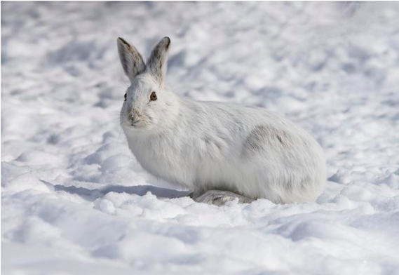

*Lepus americanus*, a keystone prey species in the Alaskan boreal forest ecosystem (photo: Sierra Club).

[figure not shown]

The long term study was located within the Bonanza Creek Experimental Forest about 25 miles southwest of Fairbanks, along a distributary of the *Tanana River*

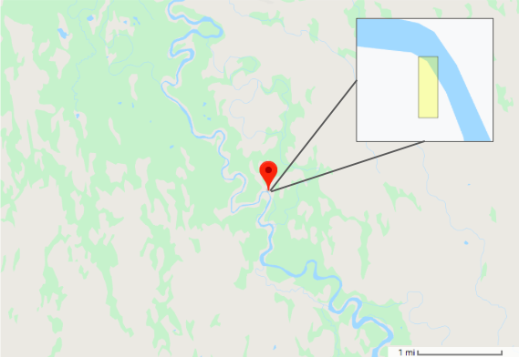

The specific bounds of the study area are: 64° 24’ 51.012’’ N - 64° 24’ 49.176’’ N, and 148° 10’ 22.908’’ W - 148° 10’ 24.24’’ W

### Data Processing

```r
##Clean the Data

# Read in Data
snowshoe_df <- read_csv("showshoe_lter.csv")

# Select Sex, Weight, Hindfoot Ratio, and Grid
# Filter Information from Grid "bonmat", as Adequate Metadata for the Site is Unavailable
# Remove Rows Containing Questionable Sex
# Convert Grid and Sex Data to Lowercase
# Remove NAs from the Dataframe
snowshoe_clean_df <- snowshoe_df %>%
  select(grid, sex, weight, age) %>%
  filter(grid != "bonmat",
         sex != "?",
         sex != "M?",
         sex != "F?",
         sex != "m?",
         sex != "f?",
         sex != "pf",
         age == "A") %>%
    mutate(grid_l = str_to_lower(grid),
           sex_l = str_to_upper(sex)) %>%
  select(-grid,
        -sex,
        -grid_l) %>%
  na.omit()
```

```r
## Summarize the Data
# Create a Summary Table of Mean Weight and Hind Foot Ratio for Each Sex
mean_table <- snowshoe_clean_df %>%
  group_by(sex_l) %>%
  summarise(mean_wt = round(mean(weight), 0),
            max_wt = round(max(weight), 1),
            min_wt  = round(min(weight), 1),
            med_wt = round(median(weight), 1))


names(mean_table) <- c("Sex", "Mean (g)", "Maximum (g)", "Minimum (g)", "Median (g)")
```

### Results

```r
## Create a Table
summary_table <- kable(mean_table,
                       caption = "Table 1: Summary of hare weights by gender") %>%
  kable_styling(bootstrap_options = "striped",
                full_width = FALSE) %>%
  add_header_above(c("Adult Snowshoe Hare Weights in the Bonanza Creek Experimental Forest" = 5))

summary_table
```

Table 1: Summary of hare weights by gender

| Adult Snowshoe Hare Weights in the Bonanza Creek Experimental Forest Sex | Adult Snowshoe Hare Weights in the Bonanza Creek Experimental Forest Mean (g) | Adult Snowshoe Hare Weights in the Bonanza Creek Experimental Forest Maximum (g) | Adult Snowshoe Hare Weights in the Bonanza Creek Experimental Forest Minimum (g) | Adult Snowshoe Hare Weights in the Bonanza Creek Experimental Forest Median (g) |
| --- | --- | --- | --- | --- |
| F | 1525 | 2365 | 720 | 1520 |
| M | 1443 | 2050 | 730 | 1460 |

While the smallest captured individual was a female, at 720 g, it is important to note that both the maximum, median, and mean weight for females are larger than those of the male hares.

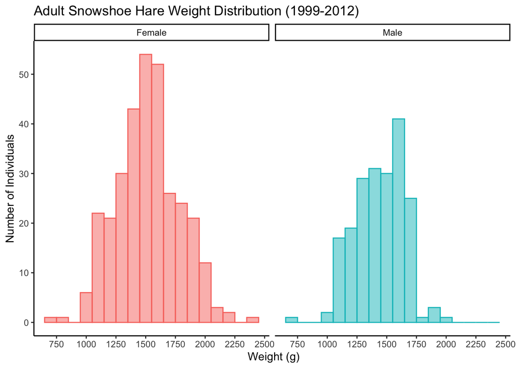

```r
## Create a Graph of the Data
labels <- c(F = "Female", M = "Male")

snowshoe_graph <- ggplot(snowshoe_clean_df, aes(x = snowshoe_clean_df$weight, color = snowshoe_clean_df$sex_l,
                                                fill = snowshoe_clean_df$sex_l), caption = "Figure 1: Distribution of all hare weights by gender") +
  geom_histogram(binwidth = 100, alpha = 0.5) +
  facet_wrap(~sex_l, labeller=labeller(sex_l = labels)) +
  scale_x_continuous(breaks = seq(500, 2500, by = 250)) +
  scale_y_continuous(breaks = seq(0, 60, by = 10)) +
  theme_classic() +
  theme(legend.position = "none") +
  labs(title="Adult Snowshoe Hare Weight Distribution (1999-2012)",x=" Weight (g)", y = "Number of Individuals", legend.title= "Sex")

snowshoe_graph
```

When intepreting the graph, it is apparent that in general the females are heavier than male hares in the same region. However, it must be noted, that there are more females than males within the entire study.